# JaleshRFXGBoost

# TFidf-W2V

```python
%%time

from gensim.models import Word2Vec
from sklearn.feature_extraction.text import TfidfVectorizer

#train, cv, test split:
xtrain, xtest, ytrain, ytest = train_test_split(df.ClenedText_W2Vtfdf, df.Score, test_size=0.2, shuffle=False)
xtr, xcv, ytr, ycv = train_test_split(xtrain, ytrain, test_size=0.2, shuffle=False)


#training list of words:
train_list = []
for sentence in xtr:
    tmp_list = []
    for word in sentence.split():
        tmp_list.append(word)
    train_list.append(tmp_list)

#cv list of words:
cv_list = []
for sentence in xcv:
    tmp_list = []
    for word in sentence.split():
        tmp_list.append(word)
    cv_list.append(tmp_list)

#test list of words:
test_list = []
for sentence in xtest:
    tmp_list = []
    for word in sentence.split():
        tmp_list.append(word)
    test_list.append(tmp_list)


#instantiating training,cv, test W2V object:

trainw2v = Word2Vec(train_list, size=1000)
cvw2v = Word2Vec(cv_list, size=1000)
testw2v = Word2Vec(test_list, size=1000)

#training word2vec List:
train_vocab = list(trainw2v.wv.vocab.keys())

#cv word2vec List:
cv_vocab = list(cvw2v.wv.vocab.keys())

#test word2vec List:
test_vocab = list(testw2v.wv.vocab.keys())
```

```
CPU times: user 1min 57s, sys: 732 ms, total: 1min 57s
Wall time: 2min
```

**TFidf vectorizer**

```python
%%time
model = TfidfVectorizer()
xtr = model.fit_transform(xtr)
xcv = model.transform(xcv)
xtest = model.transform(xtest)

# we are converting a dictionary with word as a key, and the idf as a value
dictionary = dict(zip(model.get_feature_names(), list(model.idf_)))

print(xtr.shape, xcv.shape, xtest.shape)
print(len(train_list))
```

```
(64000, 43852) (16000, 43852) (20000, 43852)
64000
CPU times: user 4.14 s, sys: 52 ms, total: 4.19 s
Wall time: 4.26 s
```

*Creating TFIDF-W2V for training data,*

*TFIDF-W2V for cv data AND*

*TFIDF-W2V for test data*

```python
import time
start = time.time()

tfidf_feat = model.get_feature_names() # tfidf words/col-names
# final_tf_idf is the sparse matrix with row= sentence, col=word and cell_val = tfidf


#tf-idf for train data:
tfidf_train_vectors = []; # the tfidf-w2v for each sentence/review is stored in this list
row=0;
for sent in train_list: # for each review/sentence
    sent_vec = np.zeros(1000) # as word vectors are of zero length
    weight_sum =0; # num of words with a valid vector in the sentence/review
    for word in sent: # for each word in a review/sentence
        if word in train_vocab and word in tfidf_feat:
            vec = trainw2v.wv[word]
            tf_idf = dictionary[word]*(sent.count(word)/len(sent))
            sent_vec += (vec * tf_idf)
            weight_sum += tf_idf
    if weight_sum != 0:
        sent_vec /= weight_sum
    tfidf_train_vectors.append(sent_vec)
    row += 1

#######################################################################################################################

#tfidf for CV data:

tfidf_cv_vectors = []; # the tfidf-w2v for each sentence/review is stored in this list
row=0;
for sent in cv_list: # for each review/sentence
    sent_vec = np.zeros(1000) # as word vectors are of zero length
    weight_sum =0; # num of words with a valid vector in the sentence/review
    for word in sent: # for each word in a review/sentence
        if word in cv_vocab and word in tfidf_feat:
            vec = cvw2v.wv[word]
            tf_idf = dictionary[word]*(sent.count(word)/len(sent))
            sent_vec += (vec * tf_idf)
            weight_sum += tf_idf
    if weight_sum != 0:
        sent_vec /= weight_sum
    tfidf_cv_vectors.append(sent_vec)
    row += 1


#######################################################################################################################



tfidf_feat = model.get_feature_names() # tfidf words/col-names
# final_tf_idf is the sparse matrix with row= sentence, col=word and cell_val = tfidf


#tfidf for Test Data:

tfidf_test_vectors = []; # the tfidf-w2v for each sentence/review is stored in this list
row=0;
for sent in test_list: # for each review/sentence
    sent_vec = np.zeros(1000) # as word vectors are of zero length
    weight_sum =0; # num of words with a valid vector in the sentence/review
    for word in sent: # for each word in a review/sentence
        if word in test_vocab and word in tfidf_feat:
            vec = testw2v.wv[word]
            tf_idf = dictionary[word]*(sent.count(word)/len(sent))
            sent_vec += (vec * tf_idf)
            weight_sum += tf_idf
    if weight_sum != 0:
        sent_vec /= weight_sum
    tfidf_test_vectors.append(sent_vec)
    row += 1


end = time.time()

print('total time taken in seconds is: ', end - start)
```

```
total time taken in seconds is:  2721.835436820984
```

```python
import psutil
```

```python
dict(psutil.virtual_memory()._asdict())
```

```
{'active': 2489413632,
 'available': 28764880896,
 'buffers': 45551616,
 'cached': 756719616,
 'free': 28354658304,
 'inactive': 582782976,
 'percent': 9.1,
 'shared': 11411456,
 'slab': 62783488,
 'total': 31628300288,
 'used': 2471370752}
```

```python
2471370752 / 31628300288 * 100
```

```
7.813795649770201
```

**conversion of list into array**

```python
%%time

import pickle

file1 = open('tfidfw2v_train.pickle', 'wb')
pickle.dump(tfidf_train_vectors, file1)
file1.close()

file1 = open('tfidfw2v_cv.pickle', 'wb')
pickle.dump(tfidf_cv_vectors, file1)
file1.close()

file1 = open('tfidfw2v_test.pickle', 'wb')
pickle.dump(tfidf_test_vectors, file1)
file1.close()
```

```
CPU times: user 1.4 s, sys: 2.46 s, total: 3.86 s
Wall time: 7.69 s
```

```python
xtr = np.array(tfidf_train_vectors)
xcv = np.array(tfidf_cv_vectors)
xtest = np.array(tfidf_test_vectors)

print(xtr.shape)
print(xcv.shape)
print(xtest.shape)
```

```
(64000, 1000)
(16000, 1000)
(20000, 1000)
```

**Tfidf-w2v RF CLASS creation**

```python
class RandomForest:

    '''building the Random Forest classifier based off hypeparameters no_of_base_models and max_depth of base_models'''

    #instantiating the instance attributes:
    def __init__(self, xtr, ytr, xcv, ycv, maximum_depth=[1, 3, 5, 7, 9, 11], estimators=[5,7,9,11,13]):
        self.xtr = xtr
        self.ytr = ytr
        self.xcv = xcv
        self.ycv = ycv
        self.estimators = estimators
        self.maximum_depth = maximum_depth

    #creating a method of calling RF classifier:
    def classfier(self, auc_dict_cv={}, auc_dict_tr={}):
        for estimator in self.estimators:
            for depths in self.maximum_depth:
                clf = RandomForestClassifier(max_depth=depths, n_estimators=estimator, oob_score=True)
                print(depths, estimator)
                clf.fit(self.xtr, self.ytr)
                y_pred_cv = clf.predict_proba(self.xcv)

                #performance metric on CV data:
                fpr_cv, tpr_cv, thresholds_cv = roc_curve(ycv, y_pred_cv[:,1])
                auc_val = auc(fpr_cv, tpr_cv)
                auc_dict_cv[auc_val] = [estimator, depths]

                #performance metrics for training data:
                y_pred_tr = clf.predict_proba(self.xtr)
                fpr_tr, tpr_tr, thresholds_tr = roc_curve(ytr, y_pred_tr[:,1])
                auc_val = auc(fpr_tr, tpr_tr)
                auc_dict_tr[auc_val] = [estimator, depths]

        return auc_dict_tr, auc_dict_cv
```

**TFIDF - W2V instance creation**

```python
import time
from sklearn.ensemble import RandomForestClassifier

start = time.time()
tfidfw2v_instance = RandomForest(xtr, ytr, xcv, ycv)

dictionary_train, dictionary_cv = tfidfw2v_instance.classfier()
end = time.time()

print('time is(in seconds): ', end - start)
```

```
1 5
3 5
5 5
7 5
9 5
11 5
1 7
3 7
5 7
7 7
9 7
11 7
1 9
3 9
5 9
```

[output cut: 16 more lines]

**sorting the list based off AUC score**

```python
#creating dictionary :

train_list = [[np.round(x, 5), y] for x, y in dictionary_train.items()]
cv_list = [[np.round(x, 5), y] for x, y in dictionary_cv.items()]

print(train_list[0])

print()
print(cv_list[0])

tr_list = sorted(train_list, key=lambda x: x[0], reverse=True)
cv_list = sorted(cv_list, key=lambda x: x[0], reverse=True)
print('sorted train list score based off AUC score is:\n', tr_list[0:3])
print('****************************************')
print()
print('sorted CV list score based off AUC score is:\n', cv_list[0:3])
```

```
[0.74557, [5, 1]]

[0.58669, [5, 1]]
sorted train list score based off AUC score is:
 [[0.97001, [13, 11]], [0.96571, [11, 11]], [0.96286, [9, 11]]]

sorted CV list score based off AUC score is:
 [[0.69779, [13, 7]], [0.69324, [13, 5]], [0.67869, [9, 5]]]
```

*Plotting AUC Curve on training and cv data based off depth*

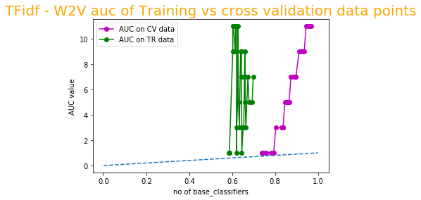

```python
plt.plot([x[0] for x in tr_list], [x[1][1] for x in tr_list], linestyle='-', color='m', marker='o',label='AUC on CV data')
plt.plot([x[0] for x in cv_list], [x[1][1] for x in cv_list], linestyle='-', color='g', marker='o', label='AUC on TR data')
plt.plot([0, 1], [0, 1], linestyle='--')
plt.xlabel("no of base_classifiers")
plt.ylabel('AUC value')
plt.title('TFidf - W2V auc of Training vs cross validation data points', size=20, color='orange')
plt.legend()
```

# 4.Optimal TFidf - W2V - RF[depth = 7 and basemodels = 13]

```python
rf = RandomForestClassifier(max_depth=7, n_estimators=13, class_weight='balanced')
rf.fit(xtr, ytr)

#prediction on training data:
y_pred_tr = rf.predict_proba(xtr)
fpr_tr, tpr_tr, thresholds_tr= roc_curve(ytr, y_pred_tr[:,1])
auc_tr = auc(fpr_tr, tpr_tr)

#prediction on test data:
ypred = rf.predict_proba(xtest)
fpr_test, tpr_test, thresholds_test= roc_curve(ytest, ypred[:,1])
auc_test = auc(fpr_test, tpr_test)

print(auc_test)
```

```
0.7680564953222484
```

*plotting confusion matrix on test data*

```
CPU times: user 0 ns, sys: 0 ns, total: 0 ns
Wall time: 6.91 µs
```

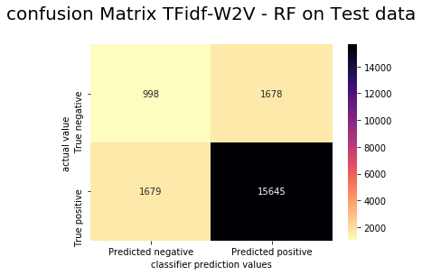

```python
%time
ypred = np.where(ypred[:,1] < 0.5, 0, 1)
#creating confusion matrix:

cf = confusion_matrix(ytest, ypred)
labels = ['True negative', 'True positive']

df_cf = pd.DataFrame(cf, index=labels, columns=['Predicted negative', 'Predicted positive'])
sns.heatmap(df_cf, annot=True,fmt='3d', cmap='magma_r')

plt.title("confusion Matrix TFidf-W2V - RF on Test data\n", size=20)
plt.xlabel("classifier prediction values")
plt.ylabel("actual value")
plt.show()
```

*plotting confusion matrix on training data*

```
CPU times: user 0 ns, sys: 0 ns, total: 0 ns
Wall time: 6.2 µs
```

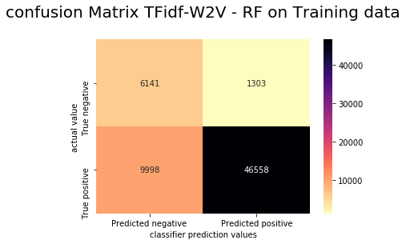

```python
%time
y_pred_tr = np.where(y_pred_tr[:,1] < 0.5, 0, 1)
#creating confusion matrix:

cf = confusion_matrix(ytr, y_pred_tr)
labels = ['True negative', 'True positive']

df_cf = pd.DataFrame(cf, index=labels, columns=['Predicted negative', 'Predicted positive'])
sns.heatmap(df_cf, annot=True,fmt='3d', cmap='magma_r')

plt.title("confusion Matrix TFidf-W2V - RF on Training data\n", size=20)
plt.xlabel("classifier prediction values")
plt.ylabel("actual value")
plt.show()
```

*plotting ROC curve on test data and training data*

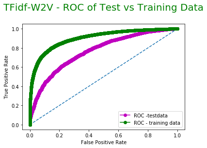

```python
plt.plot(fpr_test, tpr_test, color='m', marker='o',label='ROC -testdata')
plt.plot([0, 1], [0, 1], linestyle='--')
plt.plot(fpr_tr, tpr_tr, linestyle='-', color='g', marker='o', label='ROC - training data')
plt.xlabel('False Positive Rate')
plt.ylabel('True Positive Rate')
plt.title('TFidf-W2V - ROC of Test vs Training Data\n', size=20, color='green')
plt.legend()
```

**Plotting heatmap of CV data of AUC vs no of base models and depths**

[figure not shown]

```python
#creating dataframe for pivot table:
auc_scores = []
no_base_modesl = []
no_depths = []

for i in range(len(cv_list)):
    auc_scores.append(cv_list[i][0])
    no_base_modesl.append(cv_list[i][1][0])
    no_depths.append(cv_list[i][1][1])

df_dict = dict(base_models=no_base_modesl,
              depths=no_depths,
              auc_val=auc_scores)
d_dframe = pd.DataFrame(df_dict)
d_dframe.head(4)



#plotting heatmap:
fig = plt.figure(figsize=(6, 10), dpi=100)
d_pivot = d_dframe.pivot('auc_val','base_models', 'depths')
sns.heatmap(d_pivot, annot=True, cmap='magma_r', linecolor='black', linewidth=2)
plt.title(' Heatmap of Cross_Validation AUC value vs no_base_models and depths', size=10, color='green')
```

XGBOOST implementaion on Four vectorizers...

```python
from xgboost.sklearn import XGBClassifier
```

Train-Test-CV split...

```python
xtrain, xtest, ytrain, ytest = train_test_split(df.CleanedText_Bow, df.Score, test_size=0.2, shuffle=False)
xtr, xcv, ytr, ycv = train_test_split(xtrain, ytrain, test_size=0.2, shuffle=False)
```

BoW instantiation...

```python
from sklearn.feature_extraction.text import CountVectorizer

bow_object = CountVectorizer(ngram_range=(1,1))

xtr = bow_object.fit_transform(xtr)
xcv = bow_object.transform(xcv)
xtest = bow_object.transform(xtest)


print(xtr.shape)
print(xcv.shape)
print(xtest.shape)
```

```
(64000, 29808)
(16000, 29808)
(20000, 29808)
```

Building common XGB Class

```python
class XGB:

    '''building the XGboostRandom Forest classifier based off hypeparameters no_of_base_models and max_depth of base_models'''

    #instantiating the instance attributes:
    def __init__(self, xtr, ytr, xcv, ycv, maximum_depth=[1, 2, 3, 4], estimators=[10, 20, 30, 40, 50, 60]):
        self.xtr = xtr
        self.ytr = ytr
        self.xcv = xcv
        self.ycv = ycv
        self.estimators = estimators
        self.maximum_depth = maximum_depth

    #creating a method of calling RF classifier:
    def classfier(self, auc_dict_cv={}, auc_dict_tr={}):
        for estimator in self.estimators:
            for depths in self.maximum_depth:
                clf = XGBClassifier(booster='gbtree',silent=0,max_depth=depths, n_estimators=estimator, learning_rate=0.1)
                print(depths, estimator)
                clf.fit(self.xtr, self.ytr)
                y_pred_cv = clf.predict_proba(self.xcv)

                #performance metric on CV data:
                fpr_cv, tpr_cv, thresholds_cv = roc_curve(ycv, y_pred_cv[:,1])
                auc_val = auc(fpr_cv, tpr_cv)
                auc_dict_cv[auc_val] = [estimator, depths]

                #performance metrics for training data:
                y_pred_tr = clf.predict_proba(self.xtr)
                fpr_tr, tpr_tr, thresholds_tr = roc_curve(ytr, y_pred_tr[:,1])
                auc_val = auc(fpr_tr, tpr_tr)
                auc_dict_tr[auc_val] = [estimator, depths]

        return auc_dict_tr, auc_dict_cv
```

```python
%%time

BoW_instance = XGB(xtr, ytr, xcv, ycv)

dictionary_train, dictionary_cv = BoW_instance.classfier()
```

```
1 10
2 10
3 10
4 10
1 20
2 20
3 20
4 20
1 30
2 30
3 30
4 30
1 40
2 40
3 40
```

[output cut: 19 more lines]

Sorting the data based off AUC score

```python
train_list = [[np.round(x, 5), y] for x, y in dictionary_train.items()]
cv_list = [[np.round(x, 5), y] for x, y in dictionary_cv.items()]

print(train_list[0])

print()
print(cv_list[0])

tr_list = sorted(train_list, key=lambda x: x[0], reverse=True)
cv_list = sorted(cv_list, key=lambda x: x[0], reverse=True)
print('sorted train list score based off AUC score is:\n', tr_list[0:3])
print('****************************************')
print()
print('sorted CV list score based off AUC score is:\n', cv_list[0:3])
```

[output not shown]

AUC Curve on training and cv data based off depth

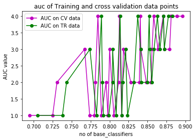

```python
plt.plot([x[0] for x in tr_list], [x[1][1] for x in tr_list], linestyle='-', color='m', marker='o',label='AUC on CV data')
plt.plot([x[0] for x in cv_list], [x[1][1] for x in cv_list], linestyle='-', color='g', marker='o', label='AUC on TR data')
#plt.plot([0, 1], [0, 1], linestyle='--')
plt.xlabel("no of base_classifiers")
plt.ylabel('AUC value')
plt.title('auc of Training and cross validation data points')
plt.legend()
```

OptimalBoW - XGBoost[depth = 4 and basemodels = 80]

```python
clfxgb = XGBClassifier(booster='gbtree',silent=0,max_depth=4, n_estimators=80, learning_rate=0.1, class_weight='balanced')
clfxgb.fit(xtr, ytr)

#prediction on training data:
y_pred_tr = clfxgb.predict_proba(xtr)
fpr_tr, tpr_tr, thresholds_tr= roc_curve(ytr, y_pred_tr[:,1])
auc_tr = auc(fpr_tr, tpr_tr)

#prediction on test data:
ypred = clfxgb.predict_proba(xtest)
fpr_test, tpr_test, thresholds_test= roc_curve(ytest, ypred[:,1])
auc_test = auc(fpr_test, tpr_test)

print(auc_test)
```

```
0.8852802962374704
```

Confusion matrix on test data

```
CPU times: user 0 ns, sys: 0 ns, total: 0 ns
Wall time: 6.2 µs
```

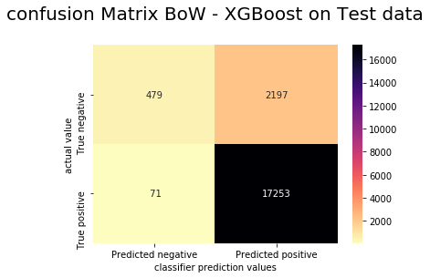

```python
%time
ypred = np.where(ypred[:,1] < 0.5, 0, 1)
#creating confusion matrix:

cf = confusion_matrix(ytest, ypred)
labels = ['True negative', 'True positive']

df_cf = pd.DataFrame(cf, index=labels, columns=['Predicted negative', 'Predicted positive'])
sns.heatmap(df_cf, annot=True,fmt='3d', cmap='magma_r')

plt.title("confusion Matrix BoW - XGBoost on Test data\n", size=20)
plt.xlabel("classifier prediction values")
plt.ylabel("actual value")
plt.show()
```

Confusion matrix on training data

```
CPU times: user 0 ns, sys: 0 ns, total: 0 ns
Wall time: 6.44 µs
```

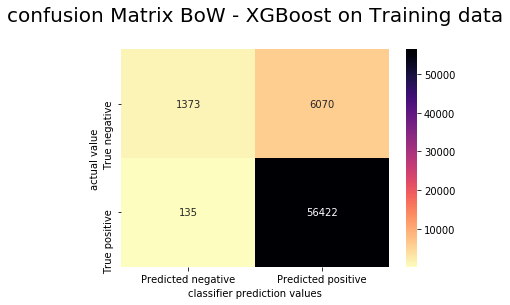

```python
%time
y_pred_tr = np.where(y_pred_tr[:,1] < 0.5, 0, 1)
#creating confusion matrix:

cf = confusion_matrix(ytr, y_pred_tr)
labels = ['True negative', 'True positive']

df_cf = pd.DataFrame(cf, index=labels, columns=['Predicted negative', 'Predicted positive'])
sns.heatmap(df_cf, annot=True,fmt='3d', cmap='magma_r')

plt.title("confusion Matrix BoW - XGBoost on Training data\n", size=20)
plt.xlabel("classifier prediction values")
plt.ylabel("actual value")
plt.show()
```

ROC curve - training vs test data

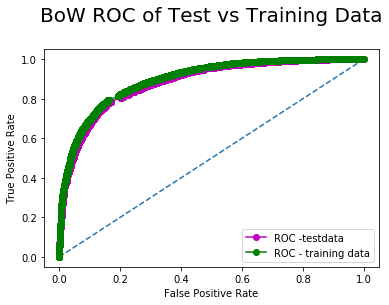

```python
plt.plot(fpr_test, tpr_test, color='m', marker='o',label='ROC -testdata')
plt.plot([0, 1], [0, 1], linestyle='--')
plt.plot(fpr_tr, tpr_tr, linestyle='-', color='g', marker='o', label='ROC - training data')
plt.xlabel('False Positive Rate')
plt.ylabel('True Positive Rate')
plt.title('BoW ROC of Test vs Training Data\n', size=20)
plt.legend()
```

Feature Importance

```python
features = bow_object.get_feature_names()
featuresAndcoeff = sorted(zip(clfxgb.feature_importances_, features))
top_features = zip(featuresAndcoeff[:25],featuresAndcoeff[:-(25+1): -1] )
print('\t\t\t\tNegative\t\t\t\t\t\t\tPositive')
print('-' * 120)

for (wn1, fn1), (wp1, fp1) in top_features:
    print('{:>20} {:>20}                                {:>20} {:>20}'.format(wn1, fn1, wp1, fp1))
```

```
				Negative							Positive
------------------------------------------------------------------------------------------------------------------------
                 0.0                  aaa                                0.027376839891076088           disappoint
                 0.0        aaaaaaaaagghh                                 0.02200981229543686               return
                 0.0               aaaaah                                 0.02034367248415947                  not
                 0.0 aaaaahhhhhhhhhhhhhhhh                                0.019724920392036438                great
                 0.0                aaaah                                 0.01964561827480793                money
                 0.0                 aaah                                 0.01670743338763714              horribl
                 0.0               aachen                                0.016628563404083252                worst
                 0.0                  aad                                0.016302969306707382              favorit
                 0.0                 aadp                                 0.01630045846104622                 best
                 0.0                aafco                                 0.01586350053548813                 love
                 0.0                 aagh                                0.015563997440040112              terribl
                 0.0                  aah                                0.015115649439394474                  bad
                 0.0                 aahh                                0.015099555253982544               delici
                 0.0                 aand                                0.015033259056508541                 mayb
                 0.0             aardvark                                0.014950428158044815                 easi
                 0.0                   ab                                0.014194663614034653              perfect
                 0.0                aback                                0.014138751663267612                bewar
                 0.0              abandon                                 0.01347731240093708                   aw
                 0.0              abaolut                                0.013415071181952953                 didn
                 0.0             abattoir                                0.013010956346988678                gross
                 0.0                 abba                                0.012943311594426632                threw
                 0.0                abbey                                0.012790671549737453                excel
                 0.0                 abbi                                0.012744717299938202                sorri
                 0.0              abbrevi                                0.012597453780472279             descript
                 0.0                  abc                                0.012104352004826069                 good
```

Since for negative class we are observing many features having feature importance values coming as 0,I m discarding all the features having 0 feature importance values and then printing the output of yop 25 features below:

```python
features = bow_object.get_feature_names()
featuresAndcoeff = sorted(zip(clfxgb.feature_importances_, features))
l = []
for a, b in featuresAndcoeff:
    if a == 0:
        continue
    else:
        l.append([a,b])

l = sorted(l, key=lambda x: x[0], reverse=True)
positive = l[:25]
negative = l[-(25 + 1): -1]
a = dict(top25_pos=positive,top25_neg=negative)
dataframe = pd.DataFrame(a)
dataframe
```

|  | top25_neg | top25_pos |
| --- | --- | --- |
| 0 | [0.0006088018, sweeten] | [0.02737684, disappoint] |
| 1 | [0.0006074863, manufactur] | [0.022009812, return] |
| 2 | [0.00060181285, ever] | [0.020343672, not] |
| 3 | [0.0005959539, sever] | [0.01972492, great] |
| 4 | [0.00058725785, don] | [0.019645618, money] |
| 5 | [0.0005866793, well] | [0.016707433, horribl] |
| 6 | [0.00058602006, experi] | [0.016628563, worst] |
| 7 | [0.00055399636, call] | [0.01630297, favorit] |
| 8 | [0.00055040594, contain] | [0.016300458, best] |
| 9 | [0.0005502545, like] | [0.0158635, love] |
| 10 | [0.0005353016, order] | [0.015563997, terribl] |
| 11 | [0.00053460075, better] | [0.015115649, bad] |
| 12 | [0.0005254598, juic] | [0.015099555, delici] |
| 13 | [0.0005103482, differ] | [0.015033259, mayb] |
| 14 | [0.00049740163, even] | [0.014950428, easi] |
| 15 | [0.0004904082, stop] | [0.014194664, perfect] |
| 16 | [0.00048564223, pound] | [0.014138752, bewar] |
| 17 | [0.00045989756, see] | [0.013477312, aw] |
| 18 | [0.00044233247, found] | [0.013415071, didn] |
| 19 | [0.00037186596, give] | [0.013010956, gross] |
| 20 | [0.00031900912, doesn] | [0.012943312, threw] |
| 21 | [0.00031846092, two] | [0.012790672, excel] |
| 22 | [0.0003037696, natur] | [0.012744717, sorri] |
| 23 | [0.00021034965, one] | [0.012597454, descript] |
| 24 | [0.00019601843, tea] | [0.012104352, good] |

Heatmap

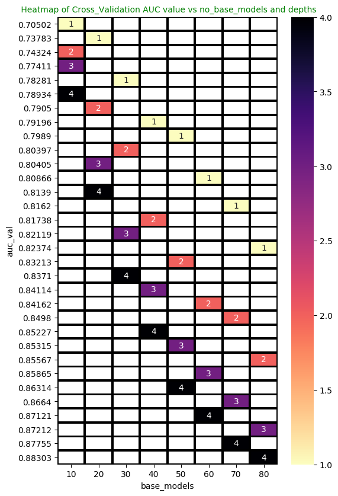

```python
#creating dataframe for pivot table:
auc_scores = []
no_base_models = []
no_depths = []

for i in range(len(cv_list)):
    auc_scores.append(cv_list[i][0])
    no_base_models.append(cv_list[i][1][0])
    no_depths.append(cv_list[i][1][1])

df_dict = dict(base_models=no_base_models,
              depths=no_depths,
              auc_val=auc_scores)
d_dframe = pd.DataFrame(df_dict)
#d_dframe.head(4)



#plotting heatmap:
fig = plt.figure(figsize=(6, 10), dpi=100)
d_pivot = d_dframe.pivot('auc_val','base_models', 'depths')
sns.heatmap(d_pivot, annot=True, cmap='magma_r', linecolor='black', linewidth=2)
plt.title(' Heatmap of Cross_Validation AUC value vs no_base_models and depths', size=10, color='green')
```

TFIDF